# Assignment 2 STATS 380

## Adjusting the getChange function to fix this issue.

```r
getChange <- function(note) {
  pieces <- strsplit(note, " was renamed to ", fixed = TRUE)[[1]]
  if (length(pieces) == 1) {
    pieces <- strsplit(note, " was renamed ", fixed = TRUE)[[1]]
  }
  yr <- getYear(note)
  from <- tryCatch(getVote(pieces[1], forwards = FALSE))
  to <- tryCatch(getVote(pieces[2], forwards = TRUE))
  structure(c(year = as.character(yr), from = from, to = to),
            names = c("year", "from", "to"))
}
changes <- lapply(renamedNotes, getChange)
head(changes, 3)
```

```
## [[1]]
##                                                 year
##                                               "1999"
##                                                 from
## "Accident Rehabilitation and Compensation Insurance"
##                                                   to
##                                 "Accident Insurance"
##
## [[2]]
##                 year                 from                   to
##               "2003" "Accident Insurance"                "ACC"
##
## [[3]]
##                   year                   from                     to
##                 "2000"     "Cultural Affairs" "Culture and Heritage"
```

```r
length(changes)
```

```
## [1] 20
```

## Creating a data frame of all the year, from and to votes.

```r
voteChanges <- do.call(rbind, lapply(changes, function(x) as.data.frame(as.list(x), stringsAsFactors = FALSE)))
voteChanges$year <- as.numeric(as.character(voteChanges$year))
rownames(voteChanges) <- NULL
head(voteChanges)
```

```
##   year                                               from
## 1 1999 Accident Rehabilitation and Compensation Insurance
## 2 2003                                 Accident Insurance
## 3 2000                                   Cultural Affairs
## 4 2000                               Culture and Heritage
## 5 2003        Energy - Energy Efficiency and Conservation
## 6 2008               Climate Change and Energy Efficiency
##                                     to
## 1                   Accident Insurance
## 2                                  ACC
## 3                 Culture and Heritage
## 4            Arts Culture and Heritage
## 5 Climate Change and Energy Efficiency
## 6                       Climate Change
```

```r
dim(voteChanges)
```

```
## [1] 20  3
```

```r
sapply(voteChanges, class)
```

```
##        year        from          to
##   "numeric" "character" "character"
```

## Graphing these changes in votes for each note.

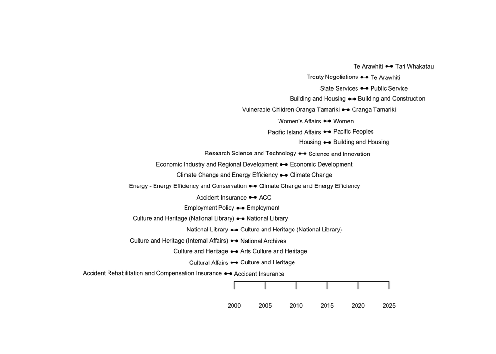

```r
o <- order(voteChanges$year, decreasing=FALSE)
voteChanges <- voteChanges[o, ]
n <- nrow(voteChanges)

# Set up empty plot with correct x/y limits
plot(NULL, xlim = c(min(voteChanges$year) - 25, max(voteChanges$year) + 10),
     ylim = c(n,1), yaxt = "n", xaxt = "n",
     xlab = "", ylab = "", bty = "n")

par(cex = 0.5)
axis(1, at = seq(2000, 2025, by = 5))

for (i in seq_len(n)) {
  y <- n - i + 1
  x <- voteChanges$year[i]
  points(c(x - 0.4, x + 0.4), rep(y, 2), pch = 16)
  lines(c(x - 0.4, x + 0.4), rep(y, 2))
  text(x - 1, y, voteChanges$from[i], adj = 1)
  text(x + 1, y, voteChanges$to[i], adj = 0)
}
```

## Summary

After filtering the notes I wanted to I was able to get the notes in which there was a rename in a vote. I was also able to figure out any inconsistencies in my filtered data set and adjust for it accordingly. In the end I was able to output a graph that showed all the renamed votes, from what they were to what they became and sorted them by the year they were changed.